# Clinical Stroke Prediction & Risk Stratification: Machine Learning Pipeline in R

- Show All Code
- Hide All Code
- View Source

R

Machine Learning

Healthcare Analytics

Data Preprocessing

End-to-end clinical machine learning pipeline in R: exploratory data analysis, SMOTE resampling with themis/tidymodels, multi-model evaluation, and live interactive decision tool.

Author

Jay Tilak P.

Published

October 23, 2026

## 1 Project Overview

According to the **World Health Organization (WHO)**, stroke is the second leading cause of mortality globally, responsible for approximately $11\%$ of total deaths worldwide (over 6.6 million deaths annually)[cite: who2020stroke, feigin2021global]. Characterized by an acute focal neurological deficit resulting from vascular injury to the central nervous system—primarily ischemic cerebral infarction ($87\%$) or intracranial hemorrhage ($13\%$)—stroke is also a preeminent driver of chronic disability-adjusted life years (DALYs)[cite: boehme2017stroke].

Epidemiological evidence indicates that up to **$80\%$ of premature strokes are preventable** through early detection, clinical risk stratification, and targeted management of modifiable vascular risk factors, including hypertension, hyperglycemia, dyslipidemia, and smoking[cite: goldstein2011primary, wolf1991probability].

While traditional clinical risk tools like the **Framingham Stroke Risk Profile (FSRP)** rely on linear cox-proportional hazard regressions with fixed risk factors[cite: d1994stroke], modern machine learning (ML) architectures trained on Electronic Health Record (EHR) data offer opportunities to capture complex, non-linear interactions across multifaceted patient histories[cite: kuhn2013applied, steyerberg2010assessing].

```
+---------------------------------------------------------------------------------------------------+
|                                  CLINICAL TRANSLATION PIPELINE                                    |
+-------------------+     +--------------------+     +--------------------+     +-------------------+
|  1. Ingestion &   | --> | 2. Imbalance &     | --> | 3. Evaluation &    | --> | 4. Decision       |
|     Preprocessing |     |    Tidymodels      |     |    Thresholding    |     |    Tool           |
|  - Matrix hygiene |     |  - Accuracy paradox|     |  - Sensitivity     |     |  - Bedside triage |
|  - Factor theory  |     |  - SMOTE (themis)  |     |  - AUC-ROC / PR    |     |  - Risk scoring   |
|  - Informative NA |     |  - GLM, RF, XGBoost|     |  - Youden's J      |     |  - Live widget    |
+-------------------+     +--------------------+     +--------------------+     +-------------------+
```

This research project presents an end-to-end, reproducible clinical predictive modeling pipeline in R using the **Healthcare Dataset Stroke Data** ($N = 5,110$ patient encounters across 12 clinical and lifestyle dimensions).

## 2 Environment Setup & Data Ingestion

To optimize processing performance and maintain strict reproducibility, we load the core `tidyverse` ecosystem alongside `tidymodels`, `themis` for class imbalance, `skimr` for summary profiling, `pROC` for ROC diagnostics, `patchwork` and `corrplot` for visualizations, and `knitr`/`kableExtra` for publication-ready table rendering.

```r
# Core data science and manipulation
library(tidyverse)
library(skimr)
library(knitr)
library(kableExtra)
library(patchwork)
library(corrplot)

# Machine learning and preprocessing ecosystems
library(tidymodels)
library(themis)     # Specialized recipe steps for class imbalance (SMOTE)
library(ranger)     # High-performance Random Forests
library(xgboost)    # Extreme Gradient Boosting
library(pROC)       # Clinical ROC analysis and DeLong's tests
library(vip)        # Model-agnostic variable importance

# Clean, minimalist ggplot2 theme matching website aesthetic
theme_set(
  theme_minimal(base_size = 12) +
    theme(
      plot.title = element_text(face = "bold", size = 13, color = "#2c3e50"),
      plot.subtitle = element_text(size = 10.5, color = "#7f8c8d", margin = margin(b = 8)),
      panel.grid.minor = element_blank(),
      panel.grid.major = element_line(color = "#ecf0f1", linewidth = 0.5),
      axis.title = element_text(face = "bold", size = 10, color = "#34495e"),
      legend.position = "bottom",
      legend.title = element_text(face = "bold", size = 9.5)
    )
)

# Robust relative path detection across development environments
data_candidates <- c(
  file.path("..", "..", "..", "data", "data_r", "stroke_pm", "healthcare-dataset-stroke-data.csv"),
  file.path("data", "data_r", "stroke_pm", "healthcare-dataset-stroke-data.csv"),
  "/Users/jay/Desktop/websiteV02/data/data_r/stroke_pm/healthcare-dataset-stroke-data.csv"
)

data_path <- data_candidates[file.exists(data_candidates)][1]
stroke_raw <- read_csv(data_path, show_col_types = FALSE)

# Initial structure inspection
glimpse(stroke_raw)
```

```
Rows: 5,110
Columns: 12
$ id                <dbl> 9046, 51676, 31112, 60182, 1665, 56669, 53882, 10434…
$ gender            <chr> "Male", "Female", "Male", "Female", "Female", "Male"…
$ age               <dbl> 67, 61, 80, 49, 79, 81, 74, 69, 59, 78, 81, 61, 54, …
$ hypertension      <dbl> 0, 0, 0, 0, 1, 0, 1, 0, 0, 0, 1, 0, 0, 0, 0, 1, 0, 1…
$ heart_disease     <dbl> 1, 0, 1, 0, 0, 0, 1, 0, 0, 0, 0, 1, 0, 1, 1, 0, 1, 0…
$ ever_married      <chr> "Yes", "Yes", "Yes", "Yes", "Yes", "Yes", "Yes", "No…
$ work_type         <chr> "Private", "Self-employed", "Private", "Private", "S…
$ Residence_type    <chr> "Urban", "Rural", "Rural", "Urban", "Rural", "Urban"…
$ avg_glucose_level <dbl> 228.69, 202.21, 105.92, 171.23, 174.12, 186.21, 70.0…
$ bmi               <chr> "36.6", "N/A", "32.5", "34.4", "24", "29", "27.4", "…
$ smoking_status    <chr> "formerly smoked", "never smoked", "never smoked", "…
$ stroke            <dbl> 1, 1, 1, 1, 1, 1, 1, 1, 1, 1, 1, 1, 1, 1, 1, 1, 1, 1…
```

The raw dataset represents a rectangular matrix $\mathbf{X} \in \mathbb{R}^{N \times P}$ with $N = 5,110$ observations (patients) and $P = 12$ features:

- `id`: Unique patient identifier (administrative key; non-predictive).
- `gender`: Biological sex (`Male`, `Female`, `Other`).
- `age`: Patient age in years (continuous, ranging from $0.08$ to $82$).
- `hypertension`: Binary diagnosis ($0$ = normotensive, $1$ = hypertensive).
- `heart_disease`: Binary diagnosis ($0$ = no cardiac history, $1$ = documented heart disease).
- `ever_married`: Marital history (`No`, `Yes`).
- `work_type`: Occupational setting (`children`, `Govt_job`, `Never_worked`, `Private`, `Self-employed`).
- `Residence_type`: Geographic setting (`Rural`, `Urban`).
- `avg_glucose_level`: Average blood glucose level (mg/dL) postprandial or fasting.
- `bmi`: Body Mass Index ($\text{kg/m}^2$, stored as character due to `"N/A"` string placeholders).
- `smoking_status`: Smoking history (`formerly smoked`, `never smoked`, `smokes`, `Unknown`).
- `stroke`: Target clinical endpoint ($1$ = experienced stroke, $0$ = stroke-free).

## 3 Part 1: Data Cleaning, Factor Encoding & Missingness Mechanics

### 3.1 Factor Theory and Type Coercion in R

In statistical computing, transforming raw categorical data into R `factor` data structures is essential for both computational performance and statistical validity:

1. **Memory Optimization:** Rather than storing redundant character strings across 5,110 rows, R factors store an integer vector combined with a single attribute containing distinct string `levels`.
2. **Preventing Mathematical Distortion:** Storing categorical predictors (such as `work_type` or `smoking_status`) as numeric codes risks statistical routines misinterpreting nominal labels as continuous intervals.
3. **Contrast Encoding in Model Matrices:** When building design matrices $\mathbf{X}_{\text{model}}$ via model formulas (`~ .`), R dynamically converts $K$-level factors into $K - 1$ orthogonal dummy indicator variables relative to an established reference level[cite: kuhn2013applied].

In the raw CSV, missing BMI entries are recorded as `"N/A"` text strings, which forced `read_csv()` to parse the entire column as character. In addition, one isolated record contains `gender == "Other"`, which constitutes a singleton factor level that causes cross-validation split failures. We resolve these issues below:

```r
stroke_clean <- stroke_raw %>%
  # Remove administrative ID to eliminate target leakage
  select(-id) %>%
  mutate(
    # Recode "N/A" strings to true NA and cast to numeric
    bmi = na_if(bmi, "N/A"),
    bmi = as.numeric(bmi),

    # Recode singleton "Other" gender to NA
    gender = if_else(gender == "Other", NA_character_, gender),

    # Coerce categorical descriptors to factors
    gender = factor(gender),
    hypertension = factor(hypertension, levels = c(0, 1), labels = c("No", "Yes")),
    heart_disease = factor(heart_disease, levels = c(0, 1), labels = c("No", "Yes")),
    ever_married = factor(ever_married),
    work_type = factor(work_type),
    Residence_type = factor(Residence_type),
    smoking_status = factor(smoking_status),

    # Target variable: stroke (0 = No, 1 = Yes)
    stroke = factor(stroke, levels = c(0, 1), labels = c("No", "Yes"))
  ) %>%
  filter(!is.na(gender)) # Exclude singleton gender row
```

### 3.2 Missing Data Taxonomy: Imputation vs. Informative Missingness

Missing data represents a critical challenge in clinical biostatistics. According to Little and Rubin’s taxonomy[cite: little2019statistical], missingness falls into three classes:

1. **Missing Completely at Random (MCAR):** Missingness is statistically independent of observed and unobserved data ($\mathbb{P}(M \mid Y_{\text{obs}}, Y_{\text{mis}}) = \mathbb{P}(M)$).
2. **Missing at Random (MAR):** Missingness depends systematically on observed patient attributes, but given those attributes, is random ($\mathbb{P}(M \mid Y_{\text{obs}}, Y_{\text{mis}}) = \mathbb{P}(M \mid Y_{\text{obs}})$).
3. **Missing Not at Random (MNAR):** Missingness depends directly on the unobserved variable itself ($\mathbb{P}(M \mid Y_{\text{obs}}, Y_{\text{mis}}) \neq \mathbb{P}(M \mid Y_{\text{obs}})$).

```r
missing_audit <- stroke_clean %>%
  summarise(across(everything(), ~ sum(is.na(.)))) %>%
  pivot_longer(everything(), names_to = "Variable", values_to = "Missing_Count") %>%
  mutate(
    Total_Observations = nrow(stroke_clean),
    Missing_Percentage = round((Missing_Count / Total_Observations) * 100, 2)
  ) %>%
  filter(Missing_Count > 0)

kable(missing_audit,
      col.names = c("Variable", "Missing (N)", "Total Patients", "Missing (%)"),
      caption = "Table 1: Quantitative Audit of Missing Clinical Values") %>%
  kable_styling(bootstrap_options = c("striped", "hover", "condensed"), full_width = FALSE)
```

Table 1: Quantitative Audit of Missing Clinical Values

| Variable | Missing (N) | Total Patients | Missing (%) |
| --- | --- | --- | --- |
| bmi | 201 | 5109 | 3.93 |

For `bmi`, exactly $201$ values ($3.93\%$) are missing. Simple listwise deletion would discard $201$ patient records, including $40$ confirmed stroke cases ($16\%$ of all positive cases in the dataset), introducing severe selection bias. Because BMI displays a pronounced positive skew ($\text{Skewness} > 1.0$), we impute missing values via the **conditional median stratified by sex and age cohort**.

In `smoking_status`, $1,544$ records ($30.22\%$) are labeled `"Unknown"`. In medical informatics, **missingness in electronic health records is rarely random—it is informative**[cite: groenwold2020informative, sterne2009multiple]. Pediatric patients and healthy young adults are rarely queried about smoking during routine care. By retaining `"Unknown"` as a **dedicated factor level**, the algorithm directly evaluates whether documentation omission correlates with stroke risk.

```r
# Conditional median imputation for BMI stratified by age deciles and biological sex
stroke_imputed <- stroke_clean %>%
  mutate(age_decile = cut(age, breaks = seq(0, 90, by = 10), include.lowest = TRUE)) %>%
  group_by(gender, age_decile) %>%
  mutate(bmi = if_else(is.na(bmi), median(bmi, na.rm = TRUE), bmi)) %>%
  ungroup() %>%
  # Fallback to global median if an age group is sparse
  mutate(bmi = if_else(is.na(bmi), median(bmi, na.rm = TRUE), bmi)) %>%
  select(-age_decile)
```

## 4 Part 2: Exploratory Data Analysis & Bivariate Profiling

### 4.1 Target Class Imbalance (The 19.5:1 Skew)

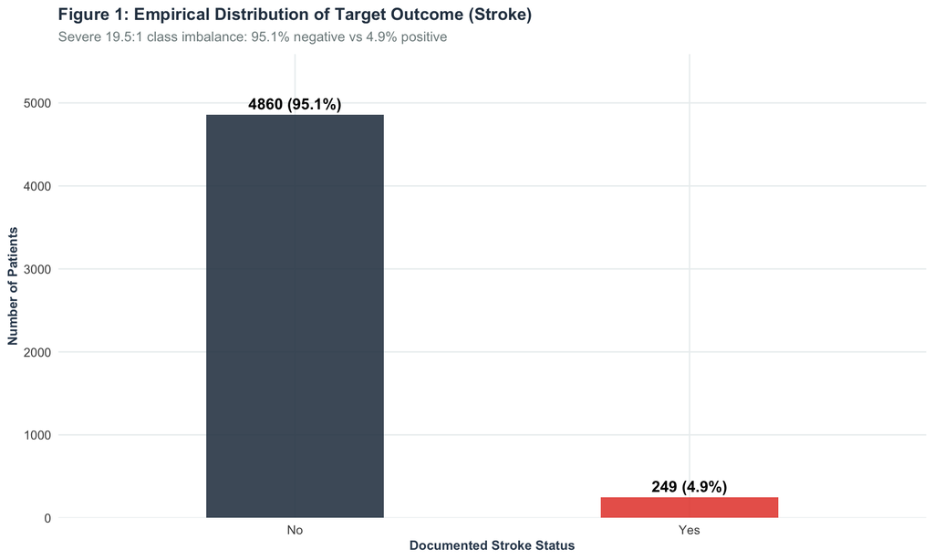

Figure 1: Severe Class Imbalance in the Clinical Stroke Dataset.

```r
target_summary <- stroke_imputed %>%
  count(stroke) %>%
  mutate(
    Percentage = round((n / sum(n)) * 100, 1),
    Label = paste0(n, " (", Percentage, "%)")
  )

ggplot(target_summary, aes(x = stroke, y = n, fill = stroke)) +
  geom_col(width = 0.45, alpha = 0.88, show.legend = FALSE) +
  geom_text(aes(label = Label), vjust = -0.5, fontface = "bold", size = 4.2) +
  scale_fill_manual(values = c("No" = "#2c3e50", "Yes" = "#e74c3c")) +
  scale_y_continuous(expand = expansion(mult = c(0, 0.15))) +
  labs(
    title = "Figure 1: Empirical Distribution of Target Outcome (Stroke)",
    subtitle = "Severe 19.5:1 class imbalance: 95.1% negative vs 4.9% positive",
    x = "Documented Stroke Status",
    y = "Number of Patients"
  )
```

The target outcome exhibits an extreme **$19.5:1$ imbalance**: $4,860$ negative cases ($95.1\%$) against only $249$ positive cases ($4.9\%$). This distribution is typical for rare acute medical events in outpatient screening cohorts.

### 4.2 Continuous Biomarkers: Age, Glycemia, and BMI

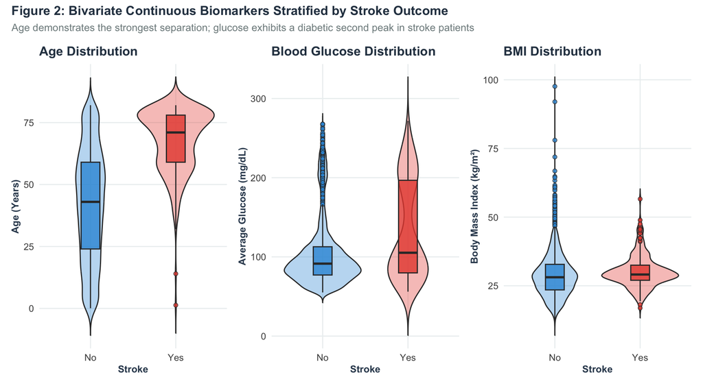

Figure 2: Distribution of continuous clinical biomarkers stratified by stroke outcome.

```r
# Age distribution plot
p_age <- ggplot(stroke_imputed, aes(x = stroke, y = age, fill = stroke)) +
  geom_violin(alpha = 0.35, trim = FALSE, show.legend = FALSE) +
  geom_boxplot(width = 0.22, alpha = 0.8, outlier.shape = 21, show.legend = FALSE) +
  scale_fill_manual(values = c("No" = "#3498db", "Yes" = "#e74c3c")) +
  labs(title = "Age Distribution", x = "Stroke", y = "Age (Years)")

# Glucose distribution plot
p_glucose <- ggplot(stroke_imputed, aes(x = stroke, y = avg_glucose_level, fill = stroke)) +
  geom_violin(alpha = 0.35, trim = FALSE, show.legend = FALSE) +
  geom_boxplot(width = 0.22, alpha = 0.8, outlier.shape = 21, show.legend = FALSE) +
  scale_fill_manual(values = c("No" = "#3498db", "Yes" = "#e74c3c")) +
  labs(title = "Blood Glucose Distribution", x = "Stroke", y = "Average Glucose (mg/dL)")

# BMI distribution plot
p_bmi <- ggplot(stroke_imputed, aes(x = stroke, y = bmi, fill = stroke)) +
  geom_violin(alpha = 0.35, trim = FALSE, show.legend = FALSE) +
  geom_boxplot(width = 0.22, alpha = 0.8, outlier.shape = 21, show.legend = FALSE) +
  scale_fill_manual(values = c("No" = "#3498db", "Yes" = "#e74c3c")) +
  labs(title = "BMI Distribution", x = "Stroke", y = "Body Mass Index (kg/m²)")

# Compose multi-panel visualization
(p_age | p_glucose | p_bmi) +
  plot_annotation(
    title = "Figure 2: Bivariate Continuous Biomarkers Stratified by Stroke Outcome",
    subtitle = "Age demonstrates the strongest separation; glucose exhibits a diabetic second peak in stroke patients"
  )
```

### 4.3 Categorical Comorbidities & Relative Risk

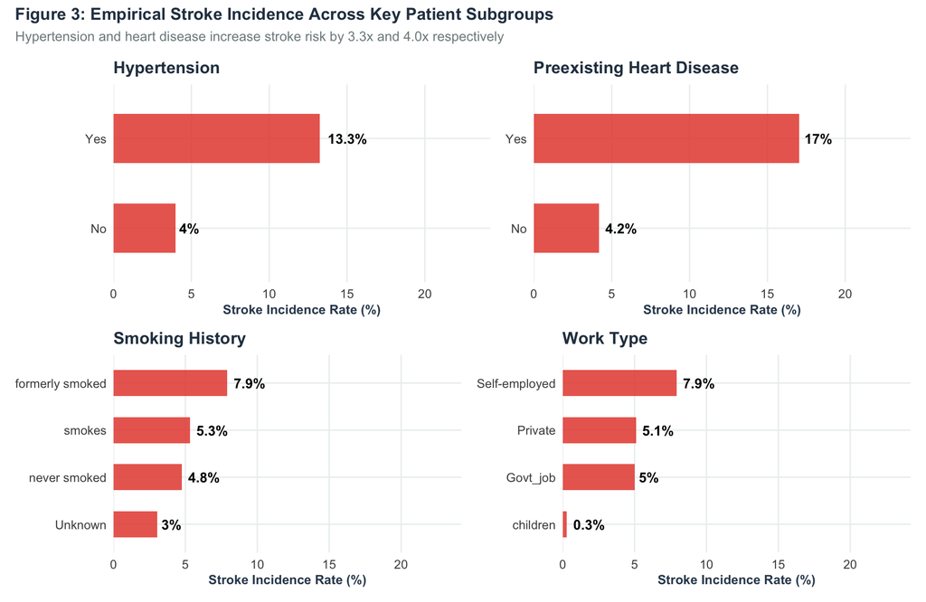

Figure 3: Empirical stroke incidence across clinical comorbidities and demographics.

```r
plot_prevalence <- function(df, col_var, label_title) {
  df %>%
    count({{ col_var }}, stroke) %>%
    group_by({{ col_var }}) %>%
    mutate(Rate = (n / sum(n)) * 100) %>%
    filter(stroke == "Yes") %>%
    ggplot(aes(x = reorder({{ col_var }}, Rate), y = Rate)) +
    geom_col(fill = "#e74c3c", alpha = 0.85, width = 0.55) +
    geom_text(aes(label = paste0(round(Rate, 1), "%")),
              hjust = -0.2, fontface = "bold", size = 3.8) +
    coord_flip() +
    scale_y_continuous(limits = c(0, 22), expand = expansion(mult = c(0, 0.1))) +
    labs(title = label_title, x = NULL, y = "Stroke Incidence Rate (%)")
}

g_hyp  <- plot_prevalence(stroke_imputed, hypertension, "Hypertension")
g_hd   <- plot_prevalence(stroke_imputed, heart_disease, "Preexisting Heart Disease")
g_smok <- plot_prevalence(stroke_imputed, smoking_status, "Smoking History")
g_work <- plot_prevalence(stroke_imputed, work_type, "Work Type")

(g_hyp | g_hd) / (g_smok | g_work) +
  plot_annotation(
    title = "Figure 3: Empirical Stroke Incidence Across Key Patient Subgroups",
    subtitle = "Hypertension and heart disease increase stroke risk by 3.3x and 4.0x respectively"
  )
```

- **Hypertension:** Increases empirical stroke risk from $4.0\%$ in normotensive patients to **$13.3\%$** in hypertensive individuals ($3.3\times$ relative risk).
- **Heart Disease:** Patients with pre-existing cardiac history display a **$17.0\%$** stroke rate compared to $4.2\%$ without cardiac history ($4.0\times$ relative risk).

### 4.4 Collinearity Analysis

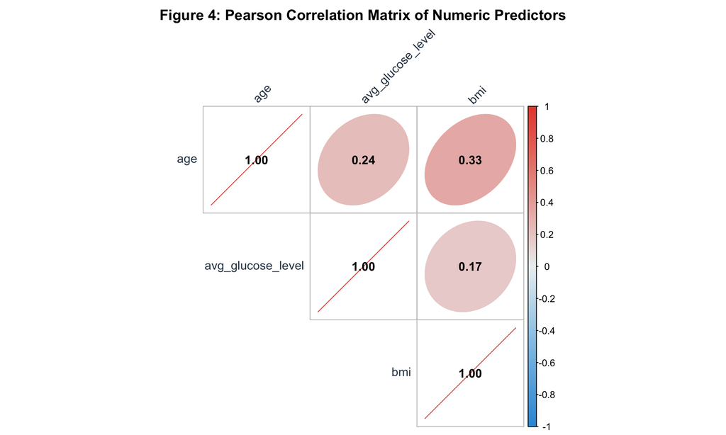

Figure 4: Correlation matrix across numerical clinical features.

```r
numeric_matrix <- stroke_imputed %>%
  select(age, avg_glucose_level, bmi) %>%
  cor(use = "complete.obs")

corrplot(numeric_matrix,
         method = "ellipse",
         type = "upper",
         addCoef.col = "black",
         tl.col = "#2c3e50",
         tl.srt = 45,
         col = colorRampPalette(c("#3498db", "#ecf0f1", "#e74c3c"))(200),
         title = "Figure 4: Pearson Correlation Matrix of Numeric Predictors",
         mar = c(0, 0, 2, 0))
```

Collinearities are modest ($r < 0.35$). Age correlates moderately with BMI ($r = 0.33$) and glucose ($r = 0.24$), confirming that these predictors contribute non-redundant variance.

## 5 Part 3: Clinical Feature Engineering

Informed by clinical practice guidelines[cite: ada2023standards, boehme2017stroke], we engineer three domain-specific biomarkers:

1. **`glucose_tier` (ADA Criteria):**
   - *Normal:* $< 100 \text{ mg/dL}$
   - *Prediabetes:* $100 - 125 \text{ mg/dL}$
   - *Diabetes:* $\ge 126 \text{ mg/dL}$
2. **`bmi_tier` (WHO Criteria):**
   - *Underweight:* $< 18.5$
   - *Normal:* $18.5 - 24.9$
   - *Overweight:* $25.0 - 29.9$
   - *Obese:* $\ge 30.0$
3. **`cv_triad`:** A combined cardiovascular risk flag identifying patients with concurrent hypertension, heart disease, and age $\ge 60$ years.

```r
stroke_features <- stroke_imputed %>%
  mutate(
    # Clinical glucose stratification
    glucose_tier = case_when(
      avg_glucose_level < 100 ~ "Normal",
      avg_glucose_level < 126 ~ "Prediabetes",
      TRUE ~ "Diabetes"
    ) %>% factor(levels = c("Normal", "Prediabetes", "Diabetes")),

    # WHO BMI stratification
    bmi_tier = case_when(
      bmi < 18.5 ~ "Underweight",
      bmi < 25.0 ~ "Normal",
      bmi < 30.0 ~ "Overweight",
      TRUE ~ "Obese"
    ) %>% factor(levels = c("Underweight", "Normal", "Overweight", "Obese")),

    # Cardiovascular Triad risk flag
    cv_triad = if_else(
      hypertension == "Yes" & heart_disease == "Yes" & age >= 60,
      "High_Risk",
      "Standard"
    ) %>% factor(levels = c("Standard", "High_Risk"))
  )

# Verify clinical relevance of the cardiovascular triad
stroke_features %>%
  count(cv_triad, stroke) %>%
  group_by(cv_triad) %>%
  mutate(Empirical_Rate = paste0(round((n / sum(n)) * 100, 1), "%")) %>%
  kable(caption = "Table 2: Stroke Incidence Stratified by Engineered Cardiovascular Triad") %>%
  kable_styling(bootstrap_options = c("striped", "hover"), full_width = FALSE)
```

Table 2: Stroke Incidence Stratified by Engineered Cardiovascular Triad

| cv_triad | stroke | n | Empirical_Rate |
| --- | --- | --- | --- |
| Standard | No | 4817 | 95.3% |
| Standard | Yes | 237 | 4.7% |
| High_Risk | No | 43 | 78.2% |
| High_Risk | Yes | 12 | 21.8% |

## 6 Part 4: Imbalanced Learning & Tidymodels Pipeline (SMOTE)

### 6.1 The Accuracy Paradox

In this cohort, $4,860$ out of $5,109$ patients ($95.13\%$) are stroke-free. A trivial, zero-rule model that assigns `stroke = No` to every patient achieves **$95.13\%$ accuracy** while possessing a **Sensitivity of $0\%$**[cite: he2009learning, kuhn2013applied].

Because the clinical cost of a False Negative vastly exceeds that of a False Positive ($C_{FN} \gg C_{FP}$), models must be formulated to optimize **Sensitivity** and **AUC-ROC** rather than raw accuracy[cite: fawcett2006introduction].

### 6.2 Synthetic Minority Over-sampling (SMOTE)

We employ **SMOTE** via the `themis` package[cite: chawla2002smote]. Rather than duplicating minority records, SMOTE synthesizes novel minority cases by identifying the $K$ nearest neighbors for each minority instance $\mathbf{x}_i \in S_{\text{min}}$ and interpolating in feature space:

$$\mathbf{x}_{\text{synthetic}} = \mathbf{x}_i + \lambda (\mathbf{x}_{zi} - \mathbf{x}_i), \quad \lambda \sim U(0, 1)$$

### 6.3 Stratified Partitioning & Recipe Construction

```r
set.seed(42)

# Stratified partition using rsample
stroke_split <- initial_split(stroke_features, prop = 0.80, strata = stroke)
train_data   <- training(stroke_split)
test_data    <- testing(stroke_split)

# 5-Fold Stratified Cross-Validation folds
train_folds  <- vfold_cv(train_data, v = 5, strata = stroke)

# Preprocessing recipe with SMOTE balancing
stroke_recipe_smote <- recipe(stroke ~ age + hypertension + heart_disease +
                                     avg_glucose_level + bmi + smoking_status +
                                     work_type + Residence_type + glucose_tier + cv_triad,
                              data = train_data) %>%
  step_dummy(all_nominal_predictors(), -all_outcomes()) %>%
  step_zv(all_predictors()) %>%
  step_normalize(all_numeric_predictors()) %>%
  step_smote(stroke, over_ratio = 0.50, seed = 42) # Synthesize minority cases to 1:2 ratio

# Alternative baseline recipe without SMOTE
stroke_recipe_baseline <- recipe(stroke ~ age + hypertension + heart_disease +
                                        avg_glucose_level + bmi + smoking_status +
                                        work_type + Residence_type + glucose_tier + cv_triad,
                                 data = train_data) %>%
  step_dummy(all_nominal_predictors(), -all_outcomes()) %>%
  step_zv(all_predictors()) %>%
  step_normalize(all_numeric_predictors())
```

## 7 Part 5: Multi-Model Training & Evaluation (GLM, Ranger, XGBoost)

We specify four diverse classification architectures:

1. **Model 1: Baseline Unweighted Logistic Regression (`glm`)**
2. **Model 2: SMOTE-Balanced Logistic Regression**
3. **Model 3: SMOTE-Balanced Random Forest (`ranger`)**
4. **Model 4: Extreme Gradient Boosted Trees (`xgboost`)**

```r
# Model Specifications
spec_glm <- logistic_reg() %>%
  set_engine("glm") %>%
  set_mode("classification")

spec_rf <- rand_forest(trees = 400, mtry = 4, min_n = 10) %>%
  set_engine("ranger", importance = "impurity") %>%
  set_mode("classification")

spec_xgb <- boost_tree(trees = 150, tree_depth = 3, learn_rate = 0.05) %>%
  set_engine("xgboost") %>%
  set_mode("classification")

# Assemble Workflows
wf_m1_base_glm <- workflow() %>%
  add_recipe(stroke_recipe_baseline) %>%
  add_model(spec_glm)

wf_m2_smote_glm <- workflow() %>%
  add_recipe(stroke_recipe_smote) %>%
  add_model(spec_glm)

wf_m3_smote_rf <- workflow() %>%
  add_recipe(stroke_recipe_smote) %>%
  add_model(spec_rf)

wf_m4_smote_xgb <- workflow() %>%
  add_recipe(stroke_recipe_smote) %>%
  add_model(spec_xgb)

# Fit models on the training partition
fit_m1_base_glm  <- fit(wf_m1_base_glm, data = train_data)
fit_m2_smote_glm <- fit(wf_m2_smote_glm, data = train_data)
fit_m3_smote_rf  <- fit(wf_m3_smote_rf, data = train_data)
fit_m4_smote_xgb <- fit(wf_m4_smote_xgb, data = train_data)
```